# Individual Assignment 2: Simple and Multiple Linear Regression by Shimony Agrawal

Download the necessary packages for Regression Analysis.

```r
# install.packages("DBI")
# install.packages("odbc")
# install.packages("dplyr")
# install.packages("tidyverse")
# install.packages("lubridate")
# install.packages("ggplot2")
# install.packages("ISLR")
# install.packages("caret")
# install.packages("forecast")
# install.packages ("corrplot")
# install.packages ("visualize")

library(DBI)
library(odbc)
library(tidyverse)
library(lubridate)
library(dplyr)
library(ggplot2)
library(ISLR)
library(caret)
library(forecast)
library(corrplot)
library(visualize)
```

```
PART 1: SIMPLE LINEAR REGRESSION
```

Task 1: For this assignment, we will use the dataset Carseats, which comes from the ISLR package. After you have installed ISLR, and used the library() function to bring this package into your environment.

```r
data(Carseats)
```

Task 2: Using ggplot,create a scatterplot that depicts the Sales variable on the y-axis and the Price variable on the x-axis. Add a best-fit line to this scatterplot.

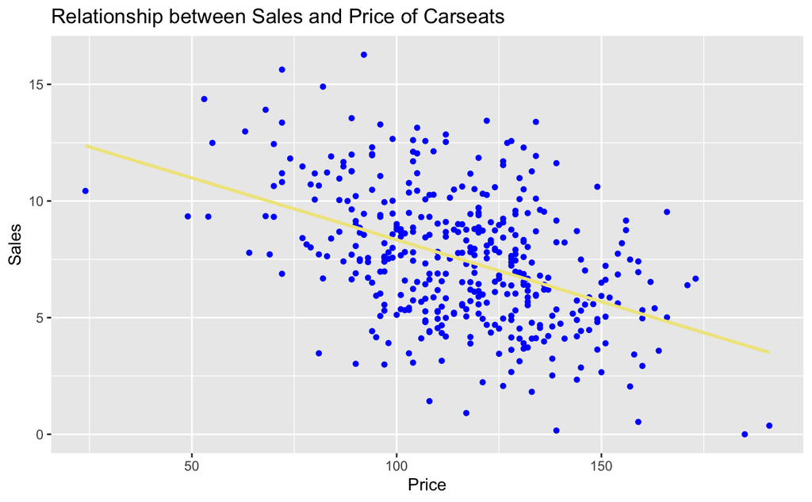

```r
ggplot(data = Carseats, aes(x = Price, y = Sales)) +
  geom_point(color = 'blue', size = 2, shape = 20)  +
  geom_smooth(method = 'lm', se = FALSE, color = 'khaki') +
  ggtitle("Relationship between Sales and Price of Carseats") +
  xlab("Price") +
  ylab("Sales")
```

Task 3: Find the correlation between these variables. Then, use cor.test() to see whether this correlation is significant.

```r
cor.test(Carseats$Sales, Carseats$Price, method = 'pearson')
```

```
    Pearson's product-moment correlation

data:  Carseats$Sales and Carseats$Price
t = -10, df = 398, p-value <2e-16
alternative hypothesis: true correlation is not equal to 0
95 percent confidence interval:
 -0.52 -0.36
sample estimates:
  cor
-0.44
```

Task 4: Using your assigned seed value, create a data partition. Assign approximately 60% of the records to your training set, and the other 40% to your validation set.

```r
nrow(Carseats) * .6  # To divide the dataset into 60% train and 40% valid
```

```
[1] 240
```

```r
set.seed(10)
Carseats_new <- sample_n(Carseats, 400)
Train <- slice(Carseats_new, 1:240)
Valid <- slice(Carseats_new, 241:400)
```

Task 5: Using your training set, create a simple linear regression model, with Sales as your outcome variable and Price as your input variable.

```r
carseat_lm <- lm(Sales ~ Price, data = Train)
summary(carseat_lm)
```

```
Call:
lm(formula = Sales ~ Price, data = Train)

Residuals:
   Min     1Q Median     3Q    Max
-6.549 -1.804 -0.099  1.688  7.403

Coefficients:
            Estimate Std. Error t value Pr(>|t|)
(Intercept)  14.0508     0.8505   16.52  < 2e-16 ***
Price        -0.0563     0.0072   -7.83  1.7e-13 ***
---
Signif. codes:  0 ‘***’ 0.001 ‘**’ 0.01 ‘*’ 0.05 ‘.’ 0.1 ‘ ’ 1

Residual standard error: 2.6 on 238 degrees of freedom
Multiple R-squared:  0.205, Adjusted R-squared:  0.201
F-statistic: 61.2 on 1 and 238 DF,  p-value: 1.65e-13
```

Task 8: Using the accuracy() function from the forecast package, assess the accuracy of your model against both the training set and the validation set.

```r
carseat_pred1 <- predict(carseat_lm, Valid)
accuracy(carseat_pred1, Valid$Sales)
```

```
             ME RMSE MAE  MPE MAPE
Test set -0.076  2.4 1.9 -Inf  Inf
```

```r
2.411565 / mean(Valid$Sales)
```

```
[1] 0.32
```

```r
carseat_pred2 <- predict(carseat_lm, Train)
accuracy(carseat_pred2, Train$Sales)
```

```
              ME RMSE MAE MPE MAPE
Test set 3.3e-15  2.6 2.1 -24   44
```

```r
2.601682 / mean(Train$Sales)
```

```
[1] 0.35
```

```
PART 2: MULTIPLE LINEAR REGRESSION
```

Task 1: Build a correlation table in R that depicts the correlations among all of the numerical variables that you might use as predictors (use your training set to build this).

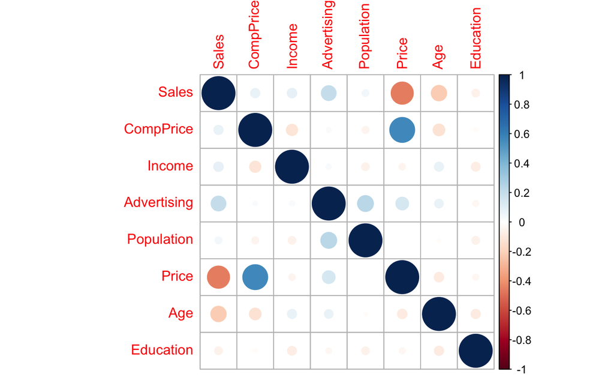

```r
Train_numeric <- subset(Train, select = -c (ShelveLoc, Urban, US))

Train.cor = cor(Train_numeric)
corrplot(Train.cor)
```

Task 3: Using backward elimination, build a multiple regression model with the data in your training set, with the goal of predicting the Sales variable.

```r
carseat_mlr <- lm(Sales ~ ., data = Train)

carseatmlr_step <- step(carseat_mlr, direction = "backward")
```

```
Start:  AIC=7.5
Sales ~ CompPrice + Income + Advertising + Population + Price +
    ShelveLoc + Age + Education + Urban + US

              Df Sum of Sq  RSS AIC
- Population   1         0  224   6
<none>                      224   8
- US           1         2  226   8
- Education    1         3  227   9
- Urban        1         4  228   9
- Income       1        33  257  38
- Advertising  1        82  306  80
- Age          1       138  362 120
- CompPrice    1       299  523 209
- ShelveLoc    2       696  920 342
- Price        1       819 1043 375

Step:  AIC=5.7
Sales ~ CompPrice + Income + Advertising + Price + ShelveLoc +
    Age + Education + Urban + US

              Df Sum of Sq  RSS AIC
<none>                      224   6
- US           1         3  227   6
- Education    1         3  228   7
- Urban        1         4  228   8
- Income       1        33  257  36
- Advertising  1        91  315  85
- Age          1       138  362 119
- CompPrice    1       299  523 207
- ShelveLoc    2       696  920 340
- Price        1       819 1043 373
```

```r
summary(carseatmlr_step)
```

```
Call:
lm(formula = Sales ~ CompPrice + Income + Advertising + Price +
    ShelveLoc + Age + Education + Urban + US, data = Train)

Residuals:
   Min     1Q Median     3Q    Max
-3.094 -0.617  0.066  0.516  3.343

Coefficients:
                Estimate Std. Error t value Pr(>|t|)
(Intercept)      6.82033    0.74490    9.16  < 2e-16 ***
CompPrice        0.08970    0.00513   17.48  < 2e-16 ***
Income           0.01407    0.00243    5.79  2.4e-08 ***
Advertising      0.13393    0.01389    9.64  < 2e-16 ***
Price           -0.09780    0.00338  -28.93  < 2e-16 ***
ShelveLocGood    4.90755    0.18657   26.30  < 2e-16 ***
ShelveLocMedium  1.86690    0.15795   11.82  < 2e-16 ***
Age             -0.04666    0.00393  -11.87  < 2e-16 ***
Education       -0.04629    0.02463   -1.88    0.061 .
UrbanYes         0.28441    0.14607    1.95    0.053 .
USYes           -0.30045    0.18519   -1.62    0.106
---
Signif. codes:  0 ‘***’ 0.001 ‘**’ 0.01 ‘*’ 0.05 ‘.’ 0.1 ‘ ’ 1

Residual standard error: 0.99 on 229 degrees of freedom
Multiple R-squared:  0.89,  Adjusted R-squared:  0.885
F-statistic:  186 on 10 and 229 DF,  p-value: <2e-16
```

Task 4: Using the variables that you will keep, build a multiple linear regression model. Show a summary of your multiple regression model.

```r
carseat_mlr1 <- lm(Sales ~ CompPrice + Income + Advertising + Price + ShelveLoc + Age, data = Train)
summary(carseat_mlr1)
```

```
Call:
lm(formula = Sales ~ CompPrice + Income + Advertising + Price +
    ShelveLoc + Age, data = Train)

Residuals:
   Min     1Q Median     3Q    Max
-2.878 -0.627  0.060  0.600  3.230

Coefficients:
                Estimate Std. Error t value Pr(>|t|)
(Intercept)      6.21387    0.63521    9.78  < 2e-16 ***
CompPrice        0.08982    0.00519   17.30  < 2e-16 ***
Income           0.01434    0.00244    5.87  1.5e-08 ***
Advertising      0.11979    0.01058   11.33  < 2e-16 ***
Price           -0.09783    0.00342  -28.61  < 2e-16 ***
ShelveLocGood    4.86268    0.18636   26.09  < 2e-16 ***
ShelveLocMedium  1.86021    0.15924   11.68  < 2e-16 ***
Age             -0.04583    0.00397  -11.56  < 2e-16 ***
---
Signif. codes:  0 ‘***’ 0.001 ‘**’ 0.01 ‘*’ 0.05 ‘.’ 0.1 ‘ ’ 1

Residual standard error: 1 on 232 degrees of freedom
Multiple R-squared:  0.886, Adjusted R-squared:  0.882
F-statistic:  257 on 7 and 232 DF,  p-value: <2e-16
```

```r
# SST

Train$outcome_diff <- Train$Sales - mean(Train$Sales)
Train$squared_diff <- Train$outcome_diff^2
sum(Train$squared_diff)
```

```
[1] 2042
```

```r
# SSR

Train$explained <- carseat_mlr1$fitted.values - mean(Train$Sales)
Train$squared_explained <- Train$explained^2
sum(Train$squared_explained)
```

```
[1] 1809
```

```r
# SSR / SST = R Square

1809.229 / 2042.488
```

```
[1] 0.89
```

Task 6: Getting from a t-value to a p-value. Choose one of the predictors from your model. What is the t-value for that predictor? Using the visualize.t() function from the visualize package, create a plot of the t-distribution that shows the distribution for that t-value and the number of degrees of freedom in your model.

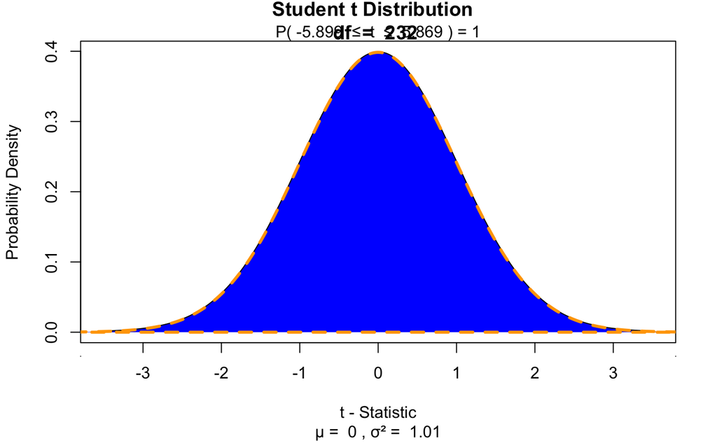

```r
# t-value of Income: 5.869
visualize.t(stat=c(-5.899, 5.869), df=232, section="bounded")
```

Task 7: Make up a fictional retail location, and assign attributes to it for each of the predictors in your model. What does your model predict that this location’s sales will be? To answer this, you can use a function in R or just explain it using the equation and some simple math.

```r
fiction <- data.frame(CompPrice = 150,
                      Income = 100 ,
                      Advertising = 25 ,
                      Price = 170 ,
                      ShelveLoc = 'Medium',
                      Age = 30)

predict (carseat_mlr1, fiction )
```

```
1
8
```

Task 8: Using the accuracy() function from the forecast package, assess the accuracy of your model against both the training set and the validation set.

```r
carseatmlr_pred1 <- predict(carseat_mlr1, Valid)
accuracy(carseatmlr_pred1, Valid$Sales)
```

```
              ME RMSE  MAE MPE MAPE
Test set -0.0049  1.1 0.89 Inf  Inf
```

```r
1.058035 / mean(Valid$Sales)
```

```
[1] 0.14
```

```r
carseatmlr_pred2 <- predict(carseat_mlr1, Train)
accuracy(carseatmlr_pred2, Train$Sales)
```

```
            ME RMSE  MAE  MPE MAPE
Test set 3e-15 0.99 0.76 -4.9   14
```

```r
0.985857 / mean(Train$Sales)
```

```
[1] 0.13
```